# Introduction to Data Science

1/25/2022

## Course information

- Lecture: Tuesdays and Thursdays
  - Teaching mode: Online (video lecture)
- Textbook: notes and resources
  - Modern Data Science with R, by Baumer, Kaplan, and Horton.
  - Additional links and references will be provided
  - Old data science class (http://mamajumder.github.io/data-science/fall-2014/index.html)
- Course page: Canvas

## Textbook

https://mdsr-book.github.io/mdsr2e/

[figure not shown]

## Self-introduction

- Instructor: Dr. Xiaoyue (Zoe) Cheng
- Email: xycheng@unomaha.edu
  - Please put the course number in the subject line.
- Office hours: (Jan 25 - May 5)
  - Tue/Thu 12-1 pm or by appointment
  - Zoom ID: 402-554-2848

## VIP instructor

- Dr. Mahbubul Majumder

[figure not shown]

## Teaching assistant

- Lakshmi Sravani Garimella
- Email: lgarimella@unomaha.edu
- Office hours: (Jan 25 - May 5)
  - Wed 4-6 pm
  - Zoom ID: 659-531-2632

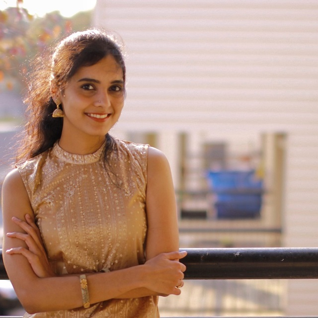

## Slack

- Enter the channel: https://join.slack.com/t/uno-stat44108416/shared_invite/zt-12bjn6829-60zYFIGJsU6HhWA9LT5~Og
- This channel will be used for informal chat with your classmates. You are welcome to ask questions or share information about data science.
- It might be easier to receive and text messages if you download the Slack app to your mobile device.

## Course outline

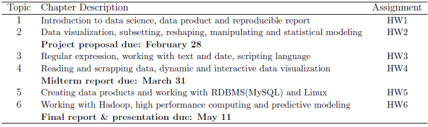

## Homework

There will be six homework assignments through the semester.

- 40% of final grade
- Can work in groups, but turn in individual work
- No late homework
- Any indication of copying will result into a zero score

### Homeworks of this class are real fun. If you don’t struggle with the HW you will not learn real. They are designed to give you the opportunity to learn through experience.

## Project Description

No exam! Submit a group project (60% of final grade).

- Form group by next week
- Each group consists of 4-5 students
- Submit real data project
  - Feb 28: proposal due
  - March 31: midterm report due
  - May 11: final report due
  - May 11: project presentation

## Why project?

- Most of your interview questions will be on the project
- Get your future career under shape (Fatten your CV)
- The reality teaches in many ways that nobody can
- Be confident
- Learn how to collaborate

## How does a project die?

How do you think a project dies after you have submitted and got grades on it?

- Throw it out and don’t look back again
- Not reproducible and lazy to do it again
- Sit and see what others did on the group and you don’t have a feel for it
- No future plan with it
- Fear competition
- Don’t want to participate
  - [Data expo](https://community.amstat.org/dataexpo/home)

## Other assignments

- Recommended reading
- Check Canvas!

## Grading

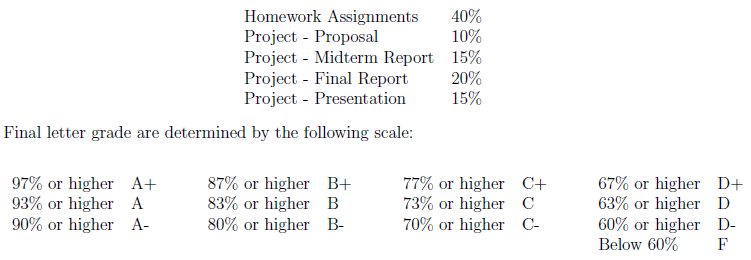

## Data Science lab

The data science lab location: DSC 243

- Data science tools are available
- Can get access to high performance computing (HCC)
- Lab user manual
- You can prepare your own machine (like the lab) for small task
- How to prepare a data science lab

## Install R and RStudio

The data science lab has both R and RStudio installed.

- Get R from http://cran.r-project.org/
- Install a typesetting software latex or Miktex from http://miktex.org/download  
  for MAC user it would be MacTex
- Get RStudio desktop version from http://www.rstudio.com/
- RStudio provides convenient environment.

### Please make sure you install them in the sequence mentioned above.

## Benefit from this course

- Tools and technics of data science
- How to create data product
- Reproducible analysis of data
- Your own data analysis project
- Contribute to a data driven society
- Not scared of data
- Not shy of data

### Are you data literate?

## Why needs data literacy?

- Industries
  - business managements
  - optimizing resource allocation and profit
  - Reliability of products and predictions
- Academics
  - Researchers running experiments producing data
  - Post docs working day and night to help researchers
  - PhD Students who are working on their dissertations

## Data Scientists are in demand

- Many industries feel the need
  - Healthcare industries are opening new positions
  - Methodist Healthcare System alone hired 6 students from our class in 2017.
- Omaha has companies employing data scientists from our program
  - TDAmeritrade
  - First National Bank
  - OPPD
  - Union Pacific
  - and more

## References

- Introduction to Data Science, Data Analysis and Prediction Algorithms with R  
  https://www.google.com/books/edition/Introduction_to_Data_Science/62K-DwAAQBAJ?hl=en&gbpv=0
- Visit our old class website of Fall 2014  
  http://mamajumder.github.io/data-science/fall-2014/index.html